# 第五章 离散时间傅里叶变换

## 模数转换（C/D）

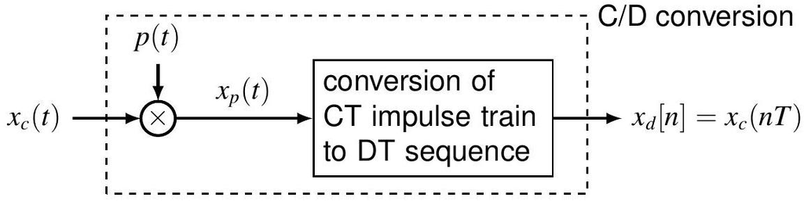

假设

- $x_{c}(t)$ 是带限信号，例如已通过低通滤波
- 采样频率高于奈奎斯特率，因此无混叠

连续时间频谱与离散时间频谱之间的关系

$$\begin{aligned}
X_{p}(j \omega) & =\mathrm{CTFT}\left\{\sum_{n \in \mathbb{Z}} x_{c}(n T) \delta(t-n T)\right\} \\
& =\sum_{n \in \mathbb{Z}} x_{c}(n T) e^{-j \omega T n}=\sum_{n \in \mathbb{Z}} x_{d}[n] e^{-j \omega T n}=X_{d}\left(e^{j \omega T}\right)
\end{aligned}$$

## 模数转换（C/D）

时域

频域

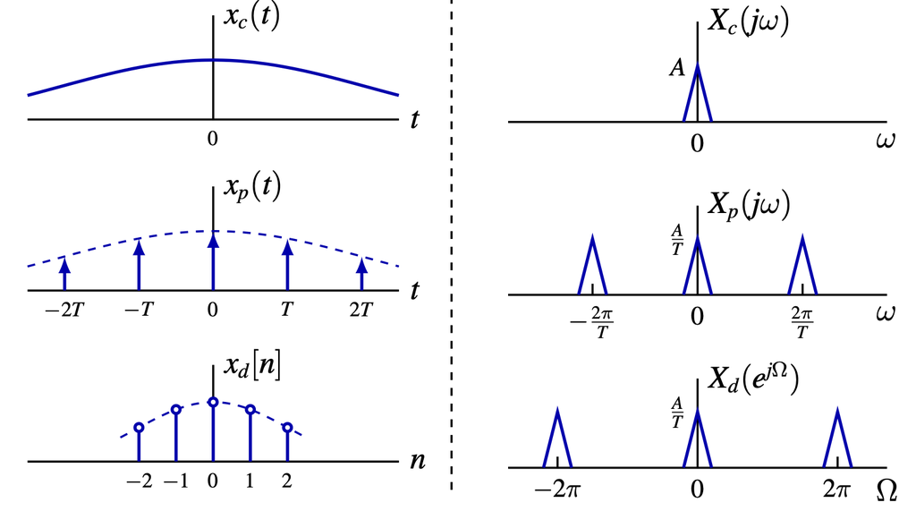

从 $x_{p}$ 到 $x_{d}$：在时间和频率两个维度上都做了归一化

## 数模转换（D/C）

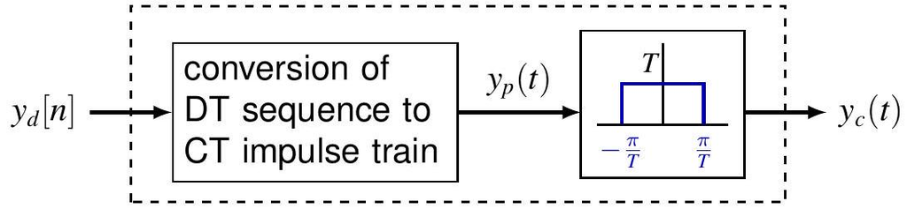

连续时间频谱与离散时间频谱之间的关系

$$\begin{aligned}
& Y_{p}(j \omega)=Y_{d}\left(e^{j \omega T}\right) \\
& Y_{c}(j \omega)= \begin{cases}Y_{p}(j \omega) & |\omega|<\frac{\omega_{s}}{2}=\frac{\omega}{T} \\
0, & \text { 否则 }\end{cases}
\end{aligned}$$

## 数模转换（D/C）

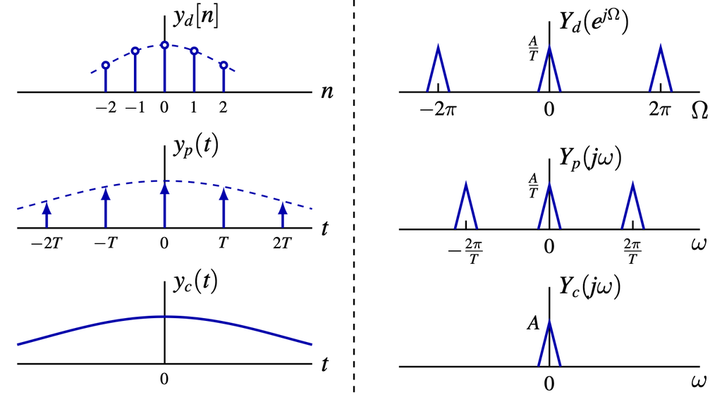

这是 C/D 转换的逆过程

## 频率响应

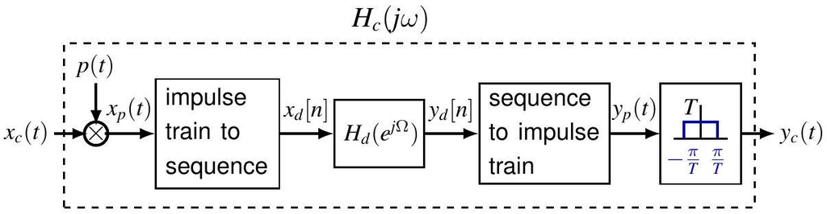

1. $Y_{d}\left(e^{j \Omega}\right)=H_{d}\left(e^{j \Omega}\right) X_{d}\left(e^{j \Omega}\right)$
2. $Y_{p}(j \omega)=Y_{d}\left(e^{j \omega T}\right)=H_{d}\left(e^{j \omega T}\right) X_{d}\left(e^{j \omega T}\right)=H_{d}\left(e^{j \omega T}\right) X_{p}(j \omega)$
3. $Y_{c}(j \omega)=Y_{p}(j \omega) H_{\mathrm{lp}}(j \omega)=H_{d}\left(e^{j \omega T}\right) X_{p}(j \omega) H_{\mathrm{lp}}(j \omega)=H_{d}\left(e^{j \omega T}\right) X_{c}(j \omega)$
4. $H_{c}(j \omega)= \begin{cases}H_{d}\left(e^{j \omega T}\right) & |\omega|<\frac{\omega_{s}}{2}=\frac{\omega}{T} \\ 0, & \text { otherwise }\end{cases}$

频率响应

$$\begin{gathered}
H_{c}(j \omega)= \begin{cases}H_{d}\left(e^{j \omega T}\right) & |\omega|<\frac{\omega_{s}}{2}=\frac{\omega}{T} \\
0, & \text { 否则 }\end{cases} \\
\Longrightarrow H_{d}\left(e^{j \Omega}\right)=H_{c}\left(j \frac{\Omega}{T}\right),|\Omega|<\pi
\end{gathered}$$

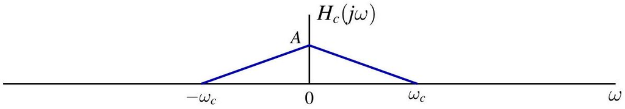

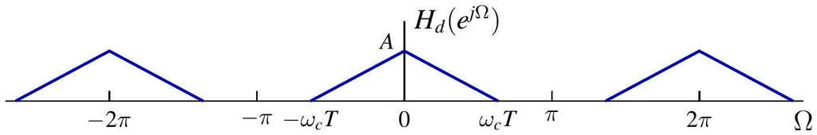

## 例: 数字微分器

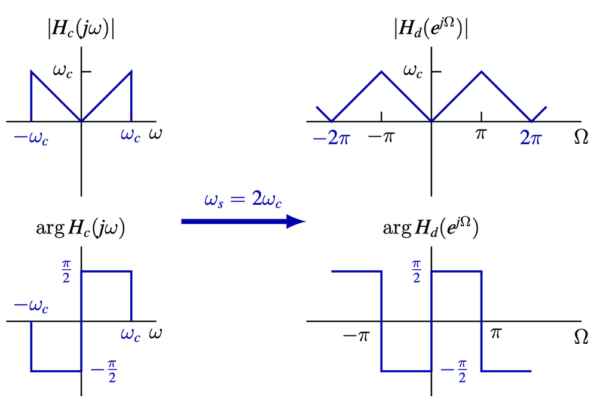

# 第五章 离散时间傅里叶变换 完